# **Rating Fusion: A Predictive Model for Soccer Player Performance**

## *INTRODUCTION*

**Soccer**, for many of us, is not merely a sport; it's a passion deeply ingrained since childhood. From the exhilarating matches on the field to the virtual battles in FIFA on PlayStations, our love for soccer has been a constant companion throughout our lives. It's this profound connection to the beautiful game that fuels our enthusiasm for delving into its intricacies through data analysis. As avid players and followers of soccer, we've often found ourselves immersed in debates over player positions and roles. With questions arising like What attributes contribute to a player's overall rating? Why is the overall rating crucial for determining a player's impact on the field? During the late-night FIFA battles with friends, sometimes experimenting with unconventional players led to surprising outcomes, unveiling the strategic nuances of the game.

> Driven by this curiosity and with the European Soccer database, we saw an opportunity to put into application the learnings of CMSC320 class.

> > In this research endeavor, we aim to predict the overall rating of a soccer player, leveraging the player-attributes encapsulated in the dataset, thus shedding light on the intricate dynamics of player roles in soccer.

**Questions to answer** :

> What factors are influential in determining the overall rating of a soccer player during a match?

> > Are there specific attributes which may have greater impact on the overall rating of a player when compared with the other attributes?

> > Are factors like age, height, weight really relevant when calculating the overall rating of a soccer player?

> Does a higher overall rating necessarily indicate better performance in matches?

**Importance** :

> Talent Identification and Development: Identifying the attributes most relevant to overall rating of a player can aid talent scouting and player development programs.

> Enhancing Team Performance: Understanding the key factors influencing a player's overall rating can help coaches and managers make informed decisions that optimize team performance.

> Fan Engagement: Analyzing player's overall rating can also enhance fan engagement by providing deeper insights into the game and sparking discussions and debates among supporters.

**Members** ---->

Member 1: Vedanta Gawande, Contribution: 90% (didn't contribute to B)  
Member 2: Shashank Pratap Singh, Contribution: 85%. (didn't contribute to F)  
Member 3: Jai Bobal, Contribution: 90%. (didn't contribute to G)

We, all team members, agree together that the above information is true, and we are confident about our contributions to this submitted project/final tutorial

> Shashank Pratap Singh, 05/07/2024

> Jai Bobal, 05/07/2024

> Vedanta Rahul Gawande, 05/07/2024

Contribution of each member :

> Vedanta : Contributed to the initial brainstorming of the project idea. Had some contributions in preprocessing the dataset (data cleaning). Mainly contributed to writing the code for the ML algorithm design/development. Also wrote the code for training and testing the ML models using MSE and R^2 statistical tests. Contributed to the first visualization in the visualization section of the project.

> Shashank : Contributed to the initial brainstorming of the project idea. Mainly worked in the initial phases of the project with data curation, preprocessing and EDA analysis. Also had helped with thought process and code for the various hypotheses tests in the EDA section. Also contributed to writing the code for the ML algorithm design/development.Worked on the overall structuring of the published html document.

> Jai : Contributed to further refining the initial brainstorming of the project idea for this project. Also worked on preprocessing and data curation of the initial raw dataset. Worked on the code for some Hypothesis tests. Worked on the idea to seperate the data entries into two for seperate analysis of the GK ratings. Contributed to the second visualization in the visualization section of the project. Worked on creating the final section (Insights and Conclusion)

## *DATA COLLECTION*

The dataset used for this research is the *European Soccer Database*, compiled by Mathien, Hugo.

It is available on Kaggle and encompasses a comprehensive collection of soccer-related data. This dataset contains information on matches, players, teams, player attributes, and more from various European soccer leagues. The dataset provides a rich source of information for analyzing player positions and roles in soccer.

For more details and access to the dataset, please visit the following link: "https://www.kaggle.com/datasets/hugomathien/soccer/data"

To use the dataset, download the zip file through the link above, extract it and import the 'database.sqlite' file into the Google Colab File. The data is now ready for processing.

Citation : Mathien, Hugo. “European Soccer Database.” Kaggle, 23 Oct. 2016, www.kaggle.com/datasets/hugomathien/soccer.

**IMPORTS**

```python
import pandas as pd
import sqlite3
import scipy.stats as stats
from statsmodels.stats.weightstats import ztest as ztest
import numpy as np
import matplotlib.pyplot as plt
import seaborn as sns
import datetime
```

### *DATA PROCESSING*

> Data processing is a vital step in preparing the dataset for analysis. It refers to the systematic manipulation and transformation of raw data into a more structured and usable format for analysis, interpretation, and decision-making purposes. This process involves various stages, including data collection, cleaning, transformation, integration, and aggregation.

> In our research, we begin by extracting relevant information from two key SQL tables: the "Player" table and the "Player Attributes" table.

```python
# First, we connect our database sqlite file.
conn = sqlite3.connect("/content/database.sqlite")
crsr = conn.cursor()

# Then, we query to find out what tables we have in our dataset.
query = "SELECT * FROM sqlite_master WHERE type = 'table'"
tables = pd.read_sql(query, conn)
tables
```

|  | type | name | tbl_name | rootpage | sql |
| --- | --- | --- | --- | --- | --- |
| 0 | table | sqlite_sequence | sqlite_sequence | 4 | CREATE TABLE sqlite_sequence(name,seq) |
| 1 | table | Player_Attributes | Player_Attributes | 11 | CREATE TABLE "Player_Attributes" (\n\t`id`\tIN... |
| 2 | table | Player | Player | 14 | CREATE TABLE `Player` (\n\t`id`\tINTEGER PRIMA... |
| 3 | table | Match | Match | 18 | CREATE TABLE `Match` (\n\t`id`\tINTEGER PRIMAR... |
| 4 | table | League | League | 24 | CREATE TABLE `League` (\n\t`id`\tINTEGER PRIMA... |
| 5 | table | Country | Country | 26 | CREATE TABLE `Country` (\n\t`id`\tINTEGER PRIM... |
| 6 | table | Team | Team | 29 | CREATE TABLE "Team" (\n\t`id`\tINTEGER PRIMARY... |
| 7 | table | Team_Attributes | Team_Attributes | 2 | CREATE TABLE `Team_Attributes` (\n\t`id`\tINTE... |

> > The "Player" table provides essential details such as player names, unique IDs, birthdays, and physical attributes like height and weight.

```python
player_query = "SELECT * FROM Player"
player_data = pd.read_sql(player_query, conn)
player_data.head()
```

|  | id | player_api_id | player_name | player_fifa_api_id | birthday | height | weight |
| --- | --- | --- | --- | --- | --- | --- | --- |
| 0 | 1 | 505942 | Aaron Appindangoye | 218353 | 1992-02-29 00:00:00 | 182.88 | 187 |
| 1 | 2 | 155782 | Aaron Cresswell | 189615 | 1989-12-15 00:00:00 | 170.18 | 146 |
| 2 | 3 | 162549 | Aaron Doran | 186170 | 1991-05-13 00:00:00 | 170.18 | 163 |
| 3 | 4 | 30572 | Aaron Galindo | 140161 | 1982-05-08 00:00:00 | 182.88 | 198 |
| 4 | 5 | 23780 | Aaron Hughes | 17725 | 1979-11-08 00:00:00 | 182.88 | 154 |

> The Player Attributes data contains specific information about each of the players in the database. Each player has a rating for every attribute, where a higher relative rating indicates better performance.

```python
player_attributes_query = "SELECT * FROM Player_Attributes"
player_attributes_data = pd.read_sql(player_attributes_query, conn)

# creating a column for athleticism which is based on the attributes like 'acceleration', 'sprint_speed', 'agility', 'reactions', 'balance', 'jumping', 'stamina', 'strength'
player_attributes_data['athleticism'] = player_attributes_data[['acceleration', 'sprint_speed', 'agility', 'reactions', 'balance', 'jumping', 'stamina', 'strength']].mean(axis=1)

# creating a column titled "general_specific_combined" for players except the goalkeeper. It is based on the attributes like 'crossing', 'finishing', 'heading_accuracy', 'volleys', 'dribbling', 'curve', 'free_kick_accuracy', 'ball_control', 'acceleration', 'sprint_speed'
player_attributes_data['general_specific_combined'] = player_attributes_data[['crossing', 'finishing', 'heading_accuracy', 'volleys', 'dribbling', 'curve', 'free_kick_accuracy', 'ball_control', 'acceleration', 'sprint_speed', 'balance', 'shot_power', 'stamina', 'strength', 'long_shots', 'interceptions', 'positioning', 'vision', 'penalties', 'marking', 'standing_tackle', 'sliding_tackle', 'curve']].mean(axis=1)

# creating a column for "gk_specific_combined" for goalkeepr. It is based on the attributes like gk_diving', 'gk_handling', 'gk_kicking', 'gk_positioning', 'gk_reflexes'
player_attributes_data['gk_specific_combined'] = player_attributes_data[['gk_diving', 'gk_handling', 'gk_kicking', 'gk_positioning', 'gk_reflexes']].mean(axis=1)

player_attributes_data.drop(columns = ['crossing', 'finishing', 'heading_accuracy', 'volleys', 'dribbling', 'curve', 'free_kick_accuracy', 'ball_control', 'acceleration', 'sprint_speed', 'balance', 'shot_power', 'stamina', 'strength', 'long_shots', 'interceptions', 'positioning', 'vision', 'penalties', 'marking', 'standing_tackle', 'sliding_tackle', 'curve', 'gk_diving', 'gk_handling', 'gk_kicking', 'gk_positioning', 'gk_reflexes'], inplace = True)

player_attributes_data.head()
```

|  | id | player_fifa_api_id | player_api_id | date | overall_rating | potential | preferred_foot | attacking_work_rate | defensive_work_rate | short_passing | long_passing | agility | reactions | jumping | aggression | athleticism | general_specific_combined | gk_specific_combined |
| --- | --- | --- | --- | --- | --- | --- | --- | --- | --- | --- | --- | --- | --- | --- | --- | --- | --- | --- |
| 0 | 1 | 218353 | 505942 | 2016-02-18 00:00:00 | 67.0 | 71.0 | right | medium | medium | 61.0 | 64.0 | 59.0 | 47.0 | 58.0 | 71.0 | 60.375 | 55.043478 | 8.6 |
| 1 | 2 | 218353 | 505942 | 2015-11-19 00:00:00 | 67.0 | 71.0 | right | medium | medium | 61.0 | 64.0 | 59.0 | 47.0 | 58.0 | 71.0 | 60.375 | 55.043478 | 8.6 |
| 2 | 3 | 218353 | 505942 | 2015-09-21 00:00:00 | 62.0 | 66.0 | right | medium | medium | 61.0 | 64.0 | 59.0 | 47.0 | 58.0 | 63.0 | 60.375 | 53.652174 | 8.6 |
| 3 | 4 | 218353 | 505942 | 2015-03-20 00:00:00 | 61.0 | 65.0 | right | medium | medium | 60.0 | 63.0 | 59.0 | 46.0 | 58.0 | 62.0 | 60.250 | 52.608696 | 7.6 |
| 4 | 5 | 218353 | 505942 | 2007-02-22 00:00:00 | 61.0 | 65.0 | right | medium | medium | 60.0 | 63.0 | 59.0 | 46.0 | 58.0 | 62.0 | 60.250 | 52.608696 | 7.6 |

> To streamline our dataset, we merge the datasets of these two tables using the merge function from the pandas library, enabling us to combine pertinent information about each player into a single coherent dataset.

> > Following the merge, we embark on basic data cleaning procedures. This involves removing redundant columns, such as duplicate entries for the same player, ensuring data integrity and accuracy. Additionally, we calculate player ages from their birthdates, a more actionable metric for our analysis.

```python
# We merge the two tables
merged_player_data = pd.merge(player_data, player_attributes_data, on='player_api_id')

# We drop the irrelevant columns.
merged_player_data.drop(columns=['player_fifa_api_id_x', 'id_y', 'id_x', 'player_fifa_api_id_y'], inplace=True)

# We drop duplicate entries in the merged dataset.
merged_player_data = merged_player_data.drop_duplicates(subset='player_name', keep='first')

# We use the birthday column to calculate the age of each of the players.
def calculate_age(birthday):
    date_str, _ = birthday.split(" ")
    birthdate = datetime.datetime.strptime(date_str, '%Y-%m-%d').date()
    today = datetime.date.today()
    age = today.year - birthdate.year - ((today.month, today.day) < (birthdate.month, birthdate.day))
    return age

# We create a new column to represent the Age of the player.
merged_player_data['age'] = merged_player_data['birthday'].apply(calculate_age)

# creating a column title "physical" which is based on the attributes - age, height, and weight
merged_player_data['physical'] = merged_player_data[['height', 'weight', 'age']].mean(axis=1)

# We then drop the birthday column as it is unnecessary now.
merged_player_data.drop(columns=['birthday', 'date'], inplace=True)

merged_player_data
```

|  | player_api_id | player_name | height | weight | overall_rating | potential | preferred_foot | attacking_work_rate | defensive_work_rate | short_passing | long_passing | agility | reactions | jumping | aggression | athleticism | general_specific_combined | gk_specific_combined | age | physical |
| --- | --- | --- | --- | --- | --- | --- | --- | --- | --- | --- | --- | --- | --- | --- | --- | --- | --- | --- | --- | --- |
| 0 | 505942 | Aaron Appindangoye | 182.88 | 187 | 67.0 | 71.0 | right | medium | medium | 61.0 | 64.0 | 59.0 | 47.0 | 58.0 | 71.0 | 60.375 | 55.043478 | 8.6 | 32 | 133.960000 |
| 5 | 155782 | Aaron Cresswell | 170.18 | 146 | 74.0 | 76.0 | left | high | medium | 71.0 | 68.0 | 78.0 | 67.0 | 85.0 | 68.0 | 76.500 | 68.695652 | 10.2 | 34 | 116.726667 |
| 38 | 162549 | Aaron Doran | 170.18 | 163 | 65.0 | 67.0 | right | medium | medium | 66.0 | 62.0 | 85.0 | 51.0 | 65.0 | 60.0 | 72.625 | 59.956522 | 12.2 | 32 | 121.726667 |
| 64 | 30572 | Aaron Galindo | 182.88 | 198 | 69.0 | 69.0 | right | medium | medium | 65.0 | 61.0 | 62.0 | 57.0 | 71.0 | 70.0 | 54.625 | 50.130435 | 12.6 | 42 | 140.960000 |
| 87 | 23780 | Aaron Hughes | 182.88 | 154 | 70.0 | 70.0 | right | medium | medium | 65.0 | 58.0 | 41.0 | 68.0 | 67.0 | 66.0 | 53.375 | 49.000000 | 10.6 | 44 | 126.960000 |
| ... | ... | ... | ... | ... | ... | ... | ... | ... | ... | ... | ... | ... | ... | ... | ... | ... | ... | ... | ... | ... |
| 183924 | 26357 | Zoumana Camara | 182.88 | 168 | 73.0 | 73.0 | right | low | medium | 70.0 | 53.0 | 62.0 | 68.0 | 84.0 | 75.0 | 65.250 | 53.521739 | 11.0 | 45 | 131.960000 |
| 183937 | 111182 | Zsolt Laczko | 182.88 | 176 | 63.0 | 67.0 | left | high | medium | 63.0 | 63.0 | 62.0 | 65.0 | 68.0 | 67.0 | 67.000 | 57.652174 | 7.0 | 37 | 131.960000 |
| 183953 | 36491 | Zsolt Low | 180.34 | 154 | 68.0 | 73.0 | left | None | _0 | 66.0 | 60.0 | 59.0 | 69.0 | 42.0 | 78.0 | 65.500 | 62.521739 | 9.0 | 45 | 126.446667 |
| 183960 | 35506 | Zurab Khizanishvili | 185.42 | 172 | 67.0 | 78.0 | right | None | _0 | 59.0 | 51.0 | 56.0 | 62.0 | 68.0 | 71.0 | 63.250 | 53.739130 | 11.6 | 42 | 133.140000 |
| 183968 | 39902 | Zvjezdan Misimovic | 180.34 | 176 | 78.0 | 78.0 | right | medium | low | 80.0 | 81.0 | 81.0 | 70.0 | 58.0 | 51.0 | 64.125 | 65.000000 | 10.0 | 41 | 132.446667 |

10848 rows × 20 columns

Removing the null values to clean the dataset and make it ready for analysis

```python
merged_player_data = merged_player_data.dropna()
print(merged_player_data.shape)
```

```
(10213, 20)
```

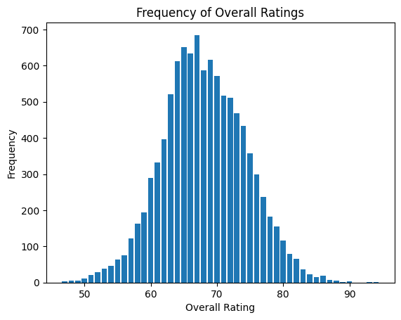

```python
# Creating a plot showing the frequency of overall ratings of the players

plt.bar(merged_player_data['overall_rating'].value_counts().index, merged_player_data['overall_rating'].value_counts().values)
plt.xlabel('Overall Rating')
plt.ylabel('Frequency')
plt.title('Frequency of Overall Ratings')
plt.show()
```

## *EXPLORATORY DATA ANALYSIS (EDA)*

> Exploratory Data Analysis (EDA) serves as a crucial preliminary step, enabling researchers to delve into the intricacies of the dataset and uncover meaningful insights. Within the context of our investigation, the EDA phase was instrumental in examining various hypotheses regarding the factors influencing the overall rating of players within our dataset. After playing around with multiple hypotheses each targeting distinct aspects of player attributes and their potential impact on overall performance ratings, we narrowed down to three main hypotheses given below.

### **Hypothesis 1**

> Our first hypothesis is centred on the premise of athletic prowess, aiming to ascertain whether athleticism directly influences a player's overall rating. We combined multiple player attributes like 'acceleration', 'sprint_speed', 'agility', 'reactions', 'balance', 'jumping', 'stamina', and 'strength' to create the ‘athleticism’ attribute.

> This hypothesis was formulated with a null hypothesis (HO) suggesting no direct influence, countered by an alternative hypothesis (HA) positing the opposite. Based on the very low p-value we concluded that ‘athleticism’ has an influence on the overall rating of a player.

HO : Athleticism doesn’t have direct influence on the overall rating of the player.

HA : Athleticism has a direct influence on the overall rating of the player.

We’ll assume the alpha-value for this to be 0.05.

```python
import scipy.stats as stats

z_score, p_value = stats.ttest_ind(merged_player_data["overall_rating"],merged_player_data["athleticism"], equal_var=False)

# Print the results of the t-test
print("Z-score:", z_score)
print("P-value:", p_value)
```

```
Z-score: 27.29715898471542
P-value: 5.16681030914185e-161
```

> Now as we can see the p-value is 5.16681030914185e-161. Also as we know higher value of p-value indicates weaker evidences for rejecting the null hypothesis and lower value of p-value indicates stronger evidences for rejecting the null hypothesis.

> Now since our p-value is less than our alpha value, 0.05. Therefore we'll reject the null hypothesis and we'll move forward with the alternative hypothesis.

> Hence we understand that Athleticism has a direct influence on the overall rating.

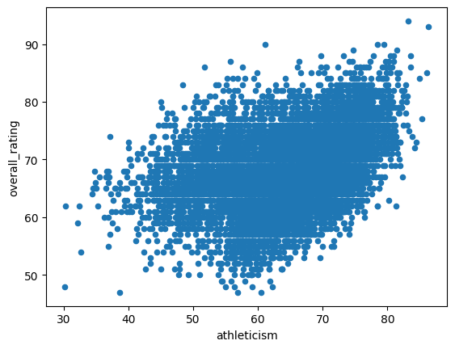

```python
# Creating a scatter plot to visualize the relation between the overall_rating and athleticism
merged_player_data.plot.scatter(x='athleticism', y='overall_rating')
```

### **Hypothesis 2**

> Our next hypothesis delved into the relationship between a player's foot preference and their overall rating. Here, the null hypothesis (HO) posited no significant effect of foot preference on overall rating, contrasting with the alternative hypothesis (HA) proposing a notable influence.

> Our p-value for this hypothesis was very high suggesting that foot preference has no significant effect on the overall rating on a player.

HO : Overall rating is not affected by a player's foot preference.

HA : Foot preference has an effect on overall rating of a player.

We'll assume the alpha-value for this to be 0.05.

```python
import scipy.stats as stats

contingency_table = pd.crosstab(merged_player_data['preferred_foot'],merged_player_data['overall_rating'])

chi2, p_value, dof, expected = stats.chi2_contingency(contingency_table)

print("Chi-square:", chi2)
print("P-value:", p_value)
```

```
Chi-square: 39.49444309545742
P-value: 0.7035933494987655
```

> As we know higher value of p-value indicates weaker evidences for rejecting the null hypothesis and lower value of p-value indicates stronger evidences for rejecting the null hypothesis.

> Now since our p-value (which is 0.7035933494987655) is greater than our alpha value, 0.05. Therefore we'll accept the null hypothesis and we'll move forward with it.

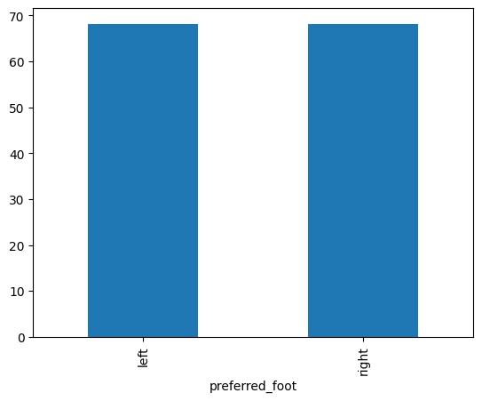

```python
merged_player_data.groupby('preferred_foot')['overall_rating'].mean().plot(kind='bar')
```

### **Hypothesis 3**

> Our last hypothesis ventured into the combined effects of age, height, and weight on a player's overall rating. Within this hypothesis, the null hypothesis (HO) suggested a collective impact of these variables on the overall rating, while the alternative hypothesis (HA) contested such an effect.

> With a very-low p-value we rejected the null hypothesis and moved forward with the alternative hypothesis which says that age, height and weight do not affect the overall rating of a player.

HO : Age, Height and Weight combined have an effect on overall rating of a player.

HA : Age, Height and Weight combined do not have an effect on overall rating of a player.

We'll assume the alpha-value for this to be 0.05.

```python
# physcial represents the combined values of the columns age, height and weight
contingency_table = pd.crosstab(merged_player_data['physical'],merged_player_data['overall_rating'])

chi2, p_value, dof, expected = stats.chi2_contingency(contingency_table)

print("Chi-square:", chi2)
print("P-value:", p_value)
```

```
Chi-square: 42533.19989985821
P-value: 9.611108417656221e-49
```

> As we know higher value of p-value indicates weaker evidences for rejecting the null hypothesis and lower value of p-value indicates stronger evidences for rejecting the null hypothesis.

> Now since our p-value (which is 9.611108417656221e-49) is less than our alpha value, 0.05. Therefore we'll reject the null hypothesis and we'll move forward with the alternate hypothesis.

> Hence we can conclude that Age, Height and Weight combined do not have an effect on overall rating of a player.

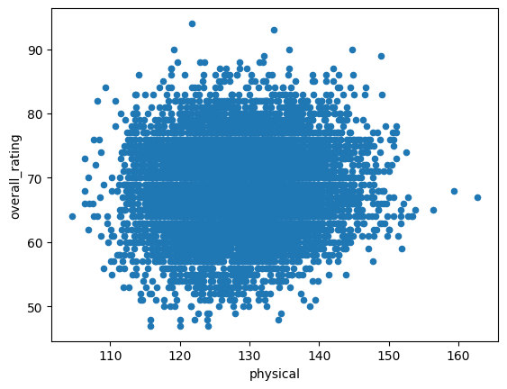

```python
# Creating a scatter plot to visualize the relation between the overall_rating and physical rating
merged_player_data.plot.scatter(x='physical', y='overall_rating')
```

## *PRIMARY ANALYSIS*

> Now, we move on to the next part of the data science pipeline → ‘Primary Analysis using Machine Learning’. In this section, we make use of the various insights we found from the Exploratory Data Analysis of our cleaned dataset to explore different machine-learning techniques that will help us answer the question posed in the introduction of this project.

> Below, we attempt to try out various machine-learning models that we learnt in class and obtain a predictive model for our data. This will help us formulate and predict the overall rating of any new players added to the database, using only their specific attributes as features.

```python
merged_player_data
```

|  | player_api_id | player_name | height | weight | overall_rating | potential | preferred_foot | attacking_work_rate | defensive_work_rate | short_passing | long_passing | agility | reactions | jumping | aggression | athleticism | general_specific_combined | gk_specific_combined | age | physical |
| --- | --- | --- | --- | --- | --- | --- | --- | --- | --- | --- | --- | --- | --- | --- | --- | --- | --- | --- | --- | --- |
| 0 | 505942 | Aaron Appindangoye | 182.88 | 187 | 67.0 | 71.0 | right | medium | medium | 61.0 | 64.0 | 59.0 | 47.0 | 58.0 | 71.0 | 60.375 | 55.043478 | 8.6 | 32 | 133.960000 |
| 5 | 155782 | Aaron Cresswell | 170.18 | 146 | 74.0 | 76.0 | left | high | medium | 71.0 | 68.0 | 78.0 | 67.0 | 85.0 | 68.0 | 76.500 | 68.695652 | 10.2 | 34 | 116.726667 |
| 38 | 162549 | Aaron Doran | 170.18 | 163 | 65.0 | 67.0 | right | medium | medium | 66.0 | 62.0 | 85.0 | 51.0 | 65.0 | 60.0 | 72.625 | 59.956522 | 12.2 | 32 | 121.726667 |
| 64 | 30572 | Aaron Galindo | 182.88 | 198 | 69.0 | 69.0 | right | medium | medium | 65.0 | 61.0 | 62.0 | 57.0 | 71.0 | 70.0 | 54.625 | 50.130435 | 12.6 | 42 | 140.960000 |
| 87 | 23780 | Aaron Hughes | 182.88 | 154 | 70.0 | 70.0 | right | medium | medium | 65.0 | 58.0 | 41.0 | 68.0 | 67.0 | 66.0 | 53.375 | 49.000000 | 10.6 | 44 | 126.960000 |
| ... | ... | ... | ... | ... | ... | ... | ... | ... | ... | ... | ... | ... | ... | ... | ... | ... | ... | ... | ... | ... |
| 183895 | 192132 | Zouhaier Dhaouadhi | 180.34 | 159 | 64.0 | 64.0 | left | medium | medium | 68.0 | 30.0 | 70.0 | 70.0 | 51.0 | 75.0 | 67.875 | 56.260870 | 10.8 | 36 | 125.113333 |
| 183903 | 282473 | Zouhair Feddal | 190.50 | 172 | 75.0 | 76.0 | left | medium | medium | 66.0 | 68.0 | 48.0 | 68.0 | 71.0 | 79.0 | 61.000 | 57.043478 | 11.4 | 35 | 132.500000 |
| 183924 | 26357 | Zoumana Camara | 182.88 | 168 | 73.0 | 73.0 | right | low | medium | 70.0 | 53.0 | 62.0 | 68.0 | 84.0 | 75.0 | 65.250 | 53.521739 | 11.0 | 45 | 131.960000 |
| 183937 | 111182 | Zsolt Laczko | 182.88 | 176 | 63.0 | 67.0 | left | high | medium | 63.0 | 63.0 | 62.0 | 65.0 | 68.0 | 67.0 | 67.000 | 57.652174 | 7.0 | 37 | 131.960000 |
| 183968 | 39902 | Zvjezdan Misimovic | 180.34 | 176 | 78.0 | 78.0 | right | medium | low | 80.0 | 81.0 | 81.0 | 70.0 | 58.0 | 51.0 | 64.125 | 65.000000 | 10.0 | 41 | 132.446667 |

10213 rows × 20 columns

The graph below shows that our data is approximately normally distributed which helps us move forward with regression analysis

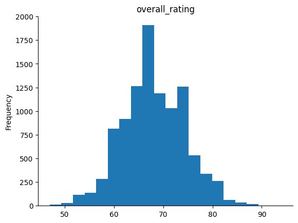

```python
merged_player_data['overall_rating'].plot(kind='hist', bins=20, title='overall_rating')
plt.gca().spines[['top', 'right',]].set_visible(False)
```

```python
from sklearn.preprocessing import OrdinalEncoder

work_rate_columns = ['attacking_work_rate', 'defensive_work_rate']
encoder = OrdinalEncoder()
encoded_work_rates = encoder.fit_transform(merged_player_data[work_rate_columns])

# Replace the old columns
merged_player_data[work_rate_columns] = encoded_work_rates

merged_player_data
```

|  | player_api_id | player_name | height | weight | overall_rating | potential | preferred_foot | attacking_work_rate | defensive_work_rate | short_passing | long_passing | agility | reactions | jumping | aggression | athleticism | general_specific_combined | gk_specific_combined | age | physical |
| --- | --- | --- | --- | --- | --- | --- | --- | --- | --- | --- | --- | --- | --- | --- | --- | --- | --- | --- | --- | --- |
| 0 | 505942 | Aaron Appindangoye | 182.88 | 187 | 67.0 | 71.0 | right | 4.0 | 14.0 | 61.0 | 64.0 | 59.0 | 47.0 | 58.0 | 71.0 | 60.375 | 55.043478 | 8.6 | 32 | 133.960000 |
| 5 | 155782 | Aaron Cresswell | 170.18 | 146 | 74.0 | 76.0 | left | 1.0 | 14.0 | 71.0 | 68.0 | 78.0 | 67.0 | 85.0 | 68.0 | 76.500 | 68.695652 | 10.2 | 34 | 116.726667 |
| 38 | 162549 | Aaron Doran | 170.18 | 163 | 65.0 | 67.0 | right | 4.0 | 14.0 | 66.0 | 62.0 | 85.0 | 51.0 | 65.0 | 60.0 | 72.625 | 59.956522 | 12.2 | 32 | 121.726667 |
| 64 | 30572 | Aaron Galindo | 182.88 | 198 | 69.0 | 69.0 | right | 4.0 | 14.0 | 65.0 | 61.0 | 62.0 | 57.0 | 71.0 | 70.0 | 54.625 | 50.130435 | 12.6 | 42 | 140.960000 |
| 87 | 23780 | Aaron Hughes | 182.88 | 154 | 70.0 | 70.0 | right | 4.0 | 14.0 | 65.0 | 58.0 | 41.0 | 68.0 | 67.0 | 66.0 | 53.375 | 49.000000 | 10.6 | 44 | 126.960000 |
| ... | ... | ... | ... | ... | ... | ... | ... | ... | ... | ... | ... | ... | ... | ... | ... | ... | ... | ... | ... | ... |
| 183895 | 192132 | Zouhaier Dhaouadhi | 180.34 | 159 | 64.0 | 64.0 | left | 4.0 | 14.0 | 68.0 | 30.0 | 70.0 | 70.0 | 51.0 | 75.0 | 67.875 | 56.260870 | 10.8 | 36 | 125.113333 |
| 183903 | 282473 | Zouhair Feddal | 190.50 | 172 | 75.0 | 76.0 | left | 4.0 | 14.0 | 66.0 | 68.0 | 48.0 | 68.0 | 71.0 | 79.0 | 61.000 | 57.043478 | 11.4 | 35 | 132.500000 |
| 183924 | 26357 | Zoumana Camara | 182.88 | 168 | 73.0 | 73.0 | right | 3.0 | 14.0 | 70.0 | 53.0 | 62.0 | 68.0 | 84.0 | 75.0 | 65.250 | 53.521739 | 11.0 | 45 | 131.960000 |
| 183937 | 111182 | Zsolt Laczko | 182.88 | 176 | 63.0 | 67.0 | left | 1.0 | 14.0 | 63.0 | 63.0 | 62.0 | 65.0 | 68.0 | 67.0 | 67.000 | 57.652174 | 7.0 | 37 | 131.960000 |
| 183968 | 39902 | Zvjezdan Misimovic | 180.34 | 176 | 78.0 | 78.0 | right | 4.0 | 13.0 | 80.0 | 81.0 | 81.0 | 70.0 | 58.0 | 51.0 | 64.125 | 65.000000 | 10.0 | 41 | 132.446667 |

10213 rows × 20 columns

Firstly, let's identify the target variable and the features set for our various models.

> As stated in the original problem statement, we are predicting the overall rating of our data. Hence, this becomes the target variable for our models.

> First, we remove these columns from the dataset as they clearly have no effect:

> > 'player_api_id': used only for identification purposes

> > 'player_name': the name of the player;

> > 'potential': This data is directly related to the overall rating and is based on the target variable we want to predict (mirrors the overall rating), so we remove this as we are trying to use the rest of the attributes for the prediction.

> Furthermore, as this data is of the String type, we would have significant problems when using this data on the machine learning models we use below as they prefer numerical data.

```python
# Creating a features DataFrame (without the irrelevant columns)
features_df = merged_player_data.drop(columns=['player_api_id', 'player_name', 'overall_rating', 'age', 'potential', 'reactions'])
```

> Coming to the rest of the features set, in the hypothesis testing in the EDA section, we found two key properties about our data and the relationship between different attributes and the overall rating.

> > The physical properties of a player, such as height and weight, do not affect the overall rating of the player.

> > The foot preference of a player (left/right) also doesn’t affect the player’s overall rating.

> These two properties are very important as they allow us to manually refine the features we use in our models. This can lead to better results in the accuracy of prediction of the overall ratings as we remove the irrelevant columns from the models allowing it to give more accurate results with less noise.

```python
features_df = features_df.drop(columns=['height', 'weight', 'physical', 'preferred_foot'])
```

> Moreover, we realized that certain attributes would hold a higher value for goalkeepers, and the same for non-goalkeeper players. This would have caused a problem for us since we would always have received a higher predicted rating for non-goalkeepers over goalkeepers.

> Thus, we chose such attributes that only apply to a specific kind of player and generated 2 new columns having the culmination of all the columns pertaining to them. This would allow us to appropriately only take into consideration the attributes that pertain to the player

```python
features_df['usable_value'] = features_df.apply(lambda row: max(row['gk_specific_combined'], row['general_specific_combined']), axis=1)
features_df.drop(columns = ['gk_specific_combined', 'general_specific_combined'], inplace = True)
```

Hence, we define the target variable and the features_df respectively.

```python
# Target variable
target = merged_player_data['overall_rating']
```

> Feature Scaling is an essential data preprocessing step in many machine learning algorithms. It aims to bring features with different scales or ranges into a comparable range. This is important because models like linear regression or distance-based algorithms (e.g., k-nearest neighbours) can be heavily influenced by features with larger magnitudes. Without scaling, features with larger ranges could dominate the model, potentially leading to biased or suboptimal predictions.

> We used the StandardScaler from scikit-learn to standardize our features. This scaler centers the data around zero (by subtracting the mean) and then scales it to have unit variance (by dividing by the standard deviation). After scaling, each feature will have a mean of zero and a standard deviation of one.

```python
# Feature Scaling (using StandardScaler)
from sklearn.preprocessing import StandardScaler
scaler = StandardScaler()
scaled_features = scaler.fit_transform(features_df)
```

> The machine learning models we use are trained on historical data to learn patterns. However, we need a way to evaluate how well they generalize to unseen data. The train-test split addresses this. We divide our dataset into two parts:

> > Training set: Used to fit the model and teach it the relationships between features and the target variable.

> > Testing set: Held out during training and used to assess the model's true performance on new data. This provides an unbiased estimate of how the model might perform in a real-world setting.

> In this code, we used scikit-learn's train_test_split function. We allocated 80% of the data for training (test_size=0.2) and the remaining 20% for testing. Setting a random_state=42 makes the splitting process reproducible, ensuring that we get the same split if we re-run the code.

```python
# Train-Test Split
from sklearn.model_selection import train_test_split
X_train, X_test, y_train, y_test = train_test_split(scaled_features, target, test_size=0.2, random_state=42)
```

## **Model Choices**

> Now, we have a dataset with known overall ratings. This makes it a supervised learning task, where the model learns from examples. (It would come under unsupervised learning if we’d not have the predefined values for overall_rating).

> Our goal is to predict a player's overall rating, which is a continuous number. Hence, this falls under the category of regression problems (not classification.)

### **Linear Regression (Baseline)**

> How it works: Finds a straight line that best represents the relationship between the features (player attributes) and the overall rating. Simple but good for understanding linear trends.

> Why It's Useful: Provides a benchmark to see how much better more complex models can do.

```python
from sklearn.linear_model import LinearRegression

model = LinearRegression()
model.fit(X_train, y_train)

# Making predictions on the test set
y_pred = model.predict(X_test)
```

### **Decision Tree Regression**

> How it works: Builds a tree-like structure with branching decisions based on the values of features. It splits the data into groups where the overall rating is similar within a group. Can capture non-linear relationships.

> Why It's Useful: More flexible than linear regression and easier to interpret than some advanced models.

```python
from sklearn.tree import DecisionTreeRegressor

tree_model = DecisionTreeRegressor()
tree_model.fit(X_train, y_train)
tree_predictions = tree_model.predict(X_test)
```

### **Random Forest Regression**

> How it works: Combines many decision trees. Each tree makes a prediction, and the final prediction is an average (or a vote) of these individual predictions. This avoids overfitting, where a single tree learns the training data too closely.

> Why It's Useful: Robust and often yields high accuracy, especially with a variety of features.

```python
from sklearn.ensemble import RandomForestRegressor

rf_model = RandomForestRegressor(n_estimators=100)  # 100 decision trees in the forest
rf_model.fit(X_train, y_train)
rf_predictions = rf_model.predict(X_test)
```

**Kindly note** : We understand that a model might memorize the training data perfectly but fail to generalize to new players. That's why we never evaluate performance solely on the training set. The test set helps simulate how well the model would perform on unseen data. This gives us a more realistic estimate of its potential accuracy.

Below we create a function called evaluate_model for calculating Mean Squared Error (MSE) and R-Squared (R2) value. This function streamlines the process of finding the r2 and mse of each model, making our code cleaner and easier to read!

```python
from sklearn.metrics import mean_squared_error, r2_score

def evaluate_model(model_name, y_test, y_pred):
    mse = mean_squared_error(y_test, y_pred)
    r2 = r2_score(y_test, y_pred)

    print(f'Model: {model_name}')
    print('Mean Squared Error (MSE):', mse)
    print('R-squared (R2):', r2)
    print('-------------------')
```

## **Evaluation Measures**

> *Mean Squared Error (MSE):* Measures the average squared difference between the predicted and actual overall ratings. Lower MSE is better. Context is key – if your overall ratings range from 40-90, an MSE of 5 is pretty good, but an MSE of 5 would be less impressive if your ratings only range from 65-75.

> *R-squared (R2):* Explains how much variance in the overall rating is captured by the model using your features. An R2 of 1 means a perfect fit, an R2 of 0 means the model is no better than just guessing the average rating. Higher R2 is better.

```python
evaluate_model('Linear Regression', y_test, y_pred)
evaluate_model('Decision Tree', y_test, tree_predictions)
evaluate_model('Random Forest', y_test, rf_predictions)
```

```
Model: Linear Regression
Mean Squared Error (MSE): 14.57559825407201
R-squared (R2): 0.6158802580310743
-------------------
Model: Decision Tree
Mean Squared Error (MSE): 19.879588839941263
R-squared (R2): 0.47610091863548387
-------------------
Model: Random Forest
Mean Squared Error (MSE): 9.374348556045032
R-squared (R2): 0.7529520033615906
-------------------
```

> The Random Forest model outperforms both the Linear Regression and Decision Tree models in terms of both MSE and R-squared.

> The Linear Regression model performs better than the Decision Tree model but worse than the Random Forest model in terms of both metrics.

> The Decision Tree model has the highest MSE and lowest R-squared among the three models, indicating poorer performance compared to the other two models.

Overall, based on these metrics, the Random Forest model appears to be the most effective in predicting the target variable, followed by the Linear Regression model, while the Decision Tree model performs the least effectively.

### *VISUALIZATION*

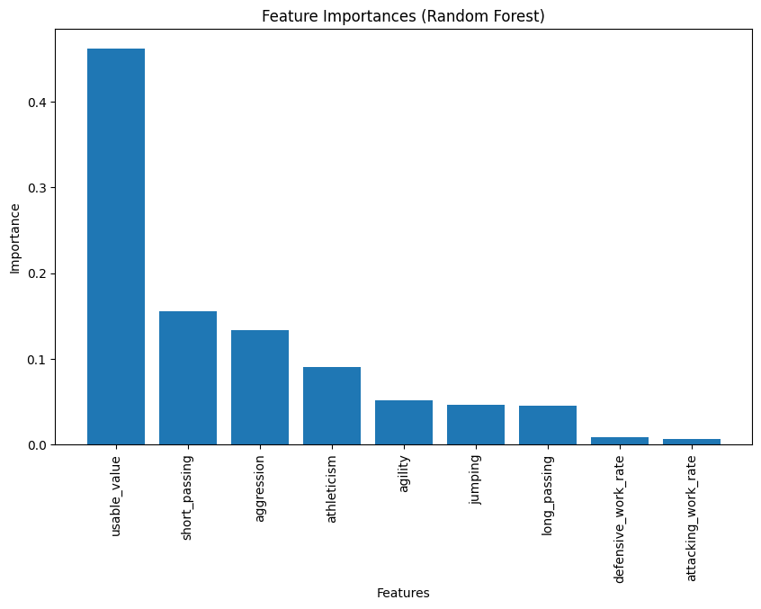

```python
import matplotlib.pyplot as plt

importances = rf_model.feature_importances_
feature_names = features_df.columns

indices = np.argsort(importances)[::-1]

plt.figure(figsize=(10,6))
plt.bar(feature_names[indices], importances[indices])
plt.xticks(rotation=90)
plt.title("Feature Importances (Random Forest)")
plt.xlabel("Features")
plt.ylabel("Importance")
plt.show()
```

This graph illustrates the relative importance assigned by our model to different attributes deemed significant in determining the overall rating of a player. the graph enables us to pinpoint which attributes have the greatest impact on the overall rating, allowing for targeted efforts to improve player performance in areas where it matters most.

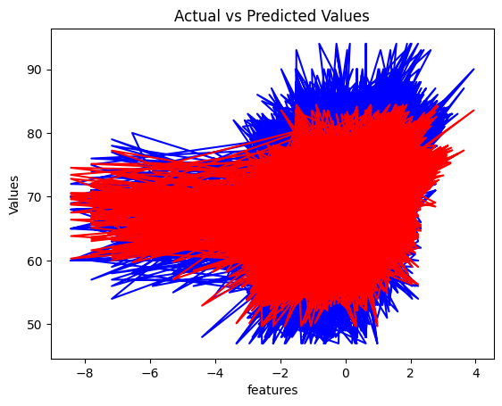

```python
plt.plot(scaled_features, merged_player_data['overall_rating'], label='Actual Values', color='blue')
plt.plot(scaled_features, model.predict(scaled_features), label='Predicted Values', color='red')

plt.xlabel('features')
plt.ylabel('Values')
plt.title('Actual vs Predicted Values')

plt.show()
```

Legend :

> Blue area : represents the original overall rating of the soccer players Red area : represents the overall rating of a player predicted by our model

This visualization illustrates the differences between the actual overall rating (blue area) of a soccer player and the one predicted by us (red area). In this graph we can see that the rough shape generated by connecting all the plots is almost similar, meaning that we're able to predict a fairly accurate overall rating of a soccer player with the given set of attributes.

### *INSIGHTS AND CONCLUSION*

Our journey through analyzing soccer player data using machine learning techniques has been both enlightening and rewarding. Through meticulous preprocessing, extensive data cleaning, and the creation of innovative parameters, we have successfully derived meaningful insights into player ratings.

One of the pivotal contributions to our analysis was the introduction of the 'usable_value' parameter. This parameter, tailored separately for goalkeepers and non-goalkeepers, played a significant role in our predictive models. By synthesizing various player attributes into a single metric, 'usable_value' became a cornerstone of our predictions. Its prominence, evidenced by its maximum feature importance in our random forest model, underscores its critical role in accurately determining player ratings.

Our exploration extended beyond mere model implementation. We delved into hypothesis testing to ascertain the influence of specific attributes on overall player ratings. This rigorous examination allowed us to validate assumptions and refine our feature selection process, ensuring that only the most impactful attributes were considered in our models. We followed all the important steps of Experimental design ranging from data cleaning to encoding to primary analysis and then leading upto visualization to understand the correlation between the various attributes of the soccer players and their impact on the overall rating of the player.

Among the diverse range of models we employed, the random forest algorithm emerged as the most effective in predicting player ratings. Its ensemble learning approach, coupled with the ability to handle complex interactions between features, enabled superior performance compared to alternative methods.

In conclusion, our comprehensive analysis of soccer player data culminated in a robust framework for predicting player ratings. Through innovative parameterization, rigorous hypothesis testing, and the selection of optimal modeling techniques, we have achieved our objective of deriving accurate player ratings from diverse attribute sets. This endeavor not only enhances our understanding of player performance but also demonstrates the efficacy of machine learning in extracting actionable insights from sports data.